# CFRM 502, Winter 2020

# Instructor: Bahman Angoshtari

# Lecture 13

**Chapter 14:** EGARCH, TGARCH, APARCH, ARIMAX + GARCH

**Chapter 15:** cointegration analysis (bivariate case)

```r
# Setting parameters of the Jupyter notebook
sc = .75
options(repr.plot.width=16*sc,
        repr.plot.height=7*sc,
        repr.plot.pointsize = 13, # Text height in pt
        repr.plot.bg        = 'white',
        repr.plot.antialias = 'gray',
        #nice medium-res DPI
        repr.plot.res       = 300,
        #jpeg quality bumped from default
        repr.plot.quality   = 90,
        #vector font family
        repr.plot.family    = 'serif')
# Vector font family. 'sans', 'serif', 'mono' or a specific one
```

$\newcommand{\1}{{\bf 1}}$ $\newcommand{\0}{{\bf 0}}$ $\newcommand\Fc{\mathscr{F}}$ $\newcommand{\eps}{\varepsilon}$ $\newcommand{\Var}{\operatorname{Var}}$ $\newcommand{\diag}{\operatorname{diag}}$ $\newcommand{\vec}{\operatorname{vec}}$ $\newcommand{\det}{\operatorname{det}}$ $\newcommand\Cov{\operatorname{Cov}}$ $\newcommand\Corr{\operatorname{Corr}}$ $\newcommand{\sig}{\sigma}$ $\newcommand\Sig{\Sigma}$ $\newcommand{\al}{\alpha}$ $\newcommand{\gam}{\gamma}$ $\newcommand\Gam{\Gamma}$ $\newcommand\lam{\lambda}$ $\newcommand{\Del}{\Delta}$ $\newcommand{\del}{\delta}$ $\newcommand\tht{\theta}$ $\newcommand\ph{\varphi}$ $\newcommand\om{\omega}$ $\newcommand\Om{\Omega}$ $\newcommand\rb{\bar{r}}$ $\newcommand{\Xb}{\bar{X}}$ $\newcommand{\Yb}{\bar{Y}}$ $\newcommand\Eb{\mathbb{E}}$ $\newcommand\Pb{\mathbb{P}}$ $\newcommand\Qb{\mathbb{Q}}$ $\newcommand\Rb{\mathbb{R}}$ $\newcommand\Zb{\mathbb{Z}}$ $\newcommand\Nb{\mathbb{N}}$ $\newcommand\Av{\textbf{A}}$ $\newcommand\av{\mathbf{a}}$ $\newcommand\Bv{\textbf{B}}$ $\newcommand\bv{\mathbf{b}}$ $\newcommand\Ev{\textbf{E}}$ $\newcommand\Dv{\textbf{D}}$ $\newcommand\Fv{\textbf{F}}$ $\newcommand\Gv{\textbf{G}}$ $\newcommand\Hv{\textbf{H}}$ $\newcommand\Kv{\textbf{K}}$ $\newcommand\Iv{\textbf{I}}$ $\newcommand\Pv{\textbf{P}}$ $\newcommand\Ov{\textbf{O}}$ $\newcommand\Sv{\textbf{S}}$ $\newcommand\Xv{\textbf{X}}$ $\newcommand\Yv{\textbf{Y}}$ $\newcommand\Zv{\textbf{Z}}$ $\newcommand\xv{\mathbf{x}}$ $\newcommand\yv{\mathbf{y}}$ $\newcommand\zv{\mathbf{z}}$ $\newcommand\Cv{\mathbf{C}}$ $\newcommand\mv{\mathbf{m}}$ $\newcommand\nv{\mathbf{n}}$ $\newcommand\pv{\mathbf{p}}$ $\newcommand\rv{\mathbf{r}}$ $\newcommand\sv{\mathbf{s}}$ $\newcommand\wv{\mathbf{w}}$ $\newcommand\Wv{\textbf{W}}$ $\newcommand\alv{{\boldsymbol\al}}$ $\newcommand\betav{{\boldsymbol\beta}}$ $\newcommand\etav{{\boldsymbol\eta}}$ $\newcommand\epsv{{\boldsymbol\varepsilon}}$ $\newcommand\delv{{\boldsymbol\delta}}$ $\newcommand\Lamv{{\boldsymbol\Lambda}}$ $\newcommand\lamv{{\boldsymbol\lambda}}$ $\newcommand\muv{{\boldsymbol\mu}}$ $\newcommand\piv{{\boldsymbol\pi}}$ $\newcommand\Piv{{\boldsymbol\Pi}}$ $\newcommand\Gamv{{\boldsymbol\Gam}}$ $\newcommand\Phiv{{\boldsymbol\Phi}}$ $\newcommand\rhov{\boldsymbol{\rho}}$ $\newcommand\Sigv{{\boldsymbol\Sig}}$ $\newcommand\ah{\widehat{a}}$ $\newcommand\Pbh{\widehat{\Pb}}$ $\newcommand\phh{\widehat{\varphi}}$ $\newcommand\Ebh{\widehat{\Eb}}$ $\newcommand\Qh{\widehat{Q}}$ $\newcommand\Ih{\widehat{I}}$ $\newcommand\rh{\widehat{r}}$ $\newcommand\pih{\widehat{\pi}}$ $\newcommand\Pih{\widehat{\Pi}}$ $\newcommand\Sigvh{\widehat{\Sigv}}$ $\newcommand\Wh{\widehat{W}}$ $\newcommand\Fh{\widehat{F}}$ $\newcommand\Yh{\widehat{Y}}$ $\newcommand\Zh{\widehat{Z}}$ $\newcommand\Yvh{\widehat{\Yv}}$ $\newcommand\Ah{\widehat{\Ac}}$ $\newcommand\uh{\widehat{u}}$ $\newcommand\vh{\widehat{v}}$ $\newcommand\fh{\widehat{f}}$ $\newcommand\hh{\widehat{h}}$ $\newcommand\Bh{\widehat{B}}$ $\newcommand\Ovh{\widehat{\Ov}}$ $\newcommand\Xvh{\widehat{\Xv}}$ $\newcommand\rhoh{\widehat{\rho}}$ $\newcommand\omh{\widehat{\om}}$ $\newcommand\nuh{\widehat{\nu}}$ $\newcommand\varphih{\widehat{\varphi}}$ $\newcommand\alh{\widehat{\al}}$ $\newcommand\thetah{\widehat{\theta}}$ $\newcommand\betah{\widehat{\beta}}$ $\newcommand\betavh{\widehat{\boldsymbol\beta}}$ $\newcommand\kaph{\widehat{\kappa}}$ $\newcommand\sigh{\widehat{\sigma}}$ $\newcommand\epsh{\widehat{\eps}}$ $\newcommand\epsvh{\widehat{\epsv}}$ $\newcommand\epst{\widetilde{\eps}}$ $\newcommand\muh{\widehat{\mu}}$ $\newcommand\dd{\mathrm{d}}$ $\newcommand\ee{\mathrm{e}}$

# 0. Overview of the lecture

- We continue the discussion of GARCH extensions:
  - IGARCH: persistence of volatility shocks (Lecture 12)
  - GARCH-M: risk premium (Lecture 12)
  - EGARCH, TGARCH, APARCH: the leverage effect
- We then consider ARIMAX+GARCH models that bring together linear regression models with ARMA+GARCH model. These models can properly address autocorrelation and non-constant variance in regression models.
- Finally, we consider bivariate cointegration analysis. This model can be used for finding long-term equilibrium between two (non-stationary) time series. It has important applications in finance, specifically, convergence trading.

# 1. Leverage effect

- Another common characteristic behavior of returns of financial assets is that the effect of return on volatility is **asymmetric**
- In particular, a large loss increase volatility more than a gain of the same size. This behavior is known as the **leverage effect**

## 1.1. Exponential GARCH (EGARCH)

- The EGARCH(p,q) model is

\begin{align*} \begin{cases} a_t = \sig_t\,\eps_t,\quad \eps_t\overset{i.i.d.}{\sim} F_\eps,\\\\ \displaystyle\ln(\sig_t^2) = \om + \sum_{i=1}^q \big(\al_i \eps_{t-i} + \gam_i (|\eps_{t-i}|-\Eb|\eps_{t-i}|)\big) + \sum_{j=1}^p \beta_j\ln(\sig_{t-j}^2). \end{cases} \end{align*}

- Note that $\Eb|\eps_{t_i}|$ is a known constant that depends on $F_\eps$. For example, if $\eps\sim N(0,1)$, then $\Eb(|\eps|)=\sqrt{2/\pi}$.
- Note, also, that standard errors $\eps_{t-i}$ appears in the volatility equation (instead of innovation $a_{t-i}$)

Features of the EGARCH model:

- EGARCH uses the log transform to relax the constraint that $\sig_t^2>0$
- We have

\begin{align*} \al_i \eps_{t-i} + \gam_i (|\eps_{t-i}|-\Eb|\eps_{t_i}|) =\begin{cases} (\al_i+\gam_i)\eps_{t-i} - \gam_i \Eb(|\eps_{t-i}|);\quad \text{if } \eps_{t-i}\ge0,\\\\ (\al_i-\gam_i)\eps_{t-i} - \gam_i \Eb(|\eps_{t-i}|);\quad \text{if } \eps_{t-i}<0.\\ \end{cases} \end{align*}

- The coefficients $(\al_i+\gam_i)$ and $(\al_i-\gam_i)$ show the asymmetry in response to positive and negative $\eps_t$. In particular, if $\al_i\ne0$, then the effect of positive and negative $\eps_{t-i}$ of the same magnitude $|\eps_{t-i}|$ is different. For this reason, $\al_i$ is called the **leverage parameter**.
- $\al_i$ represents the effect of the sign of $\eps_{t-i}$. $\gam_i$ represents the effect of the magnitude of $\eps_{t-i}$.
- If $\al_i\ne0$, the model is **non-linear**
- Let us fit an EGARCH(1,1) model to the monthly excess return of S&P 500.

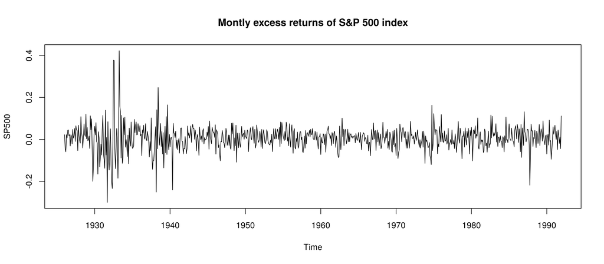

```r
rtn = ts(read.table("m-SP500.txt", header=TRUE), start=c(1926,1), frequency=12)
plot(rtn, main="Montly excess returns of S&P 500 index")
```

- We can do so by `ugarchfit()` function. Simply choose `model="eGARCH"` as the variance model.
- The fitted model is

\begin{align*} \begin{cases} a_t = 0.006865 + \sig_t\,\eps_t,\quad \eps_t\overset{i.i.d.}{\sim} N(0,1),\\\\ \displaystyle\ln(\sig_t^2) = -0.153514 -0.058325\, \eps_{t-1}\\ \qquad\qquad+ 0.226980\, (|\eps_{t-1}|-\sqrt{2/\pi}) + 0.973449\,\ln(\sig_{t-1}^2). \end{cases} \end{align*}

- The lag-1 leverage parameter $\al_1=-0.058325$ is significant (p-value is 0.009117). So, the model implies leverage effect in the S&P 500 returns.

```r
library(rugarch)
spec = ugarchspec(variance.model=list(model="eGARCH", garchOrder=c(1,1)),
                  mean.model=list(armaOrder=c(0,0)))
fit_egarch = ugarchfit(data=rtn, spec=spec)
show(fit_egarch)
```

```
*---------------------------------*
*          GARCH Model Fit        *
*---------------------------------*

Conditional Variance Dynamics
-----------------------------------
GARCH Model	: eGARCH(1,1)
Mean Model	: ARFIMA(0,0,0)
Distribution	: norm

Optimal Parameters
------------------------------------
        Estimate  Std. Error  t value Pr(>|t|)
mu      0.006865    0.001552   4.4225 0.000010
omega  -0.153514    0.056374  -2.7232 0.006466
alpha1 -0.058325    0.022367  -2.6076 0.009117
beta1   0.973449    0.009257 105.1571 0.000000
gamma1  0.226980    0.033927   6.6902 0.000000

Robust Standard Errors:
        Estimate  Std. Error  t value Pr(>|t|)
mu      0.006865    0.001699   4.0395 0.000054
omega  -0.153514    0.073875  -2.0780 0.037707
alpha1 -0.058325    0.030263  -1.9273 0.053947
beta1   0.973449    0.011611  83.8414 0.000000
gamma1  0.226980    0.044154   5.1407 0.000000

LogLikelihood : 1271.916

Information Criteria
------------------------------------

Akaike       -3.1993
Bayes        -3.1698
Shibata      -3.1994
Hannan-Quinn -3.1879

Weighted Ljung-Box Test on Standardized Residuals
------------------------------------
                        statistic p-value
```

[output cut: 39 more lines]

```
Negative Sign Bias  1.1913 0.233895
Positive Sign Bias  0.3372 0.736063
Joint Effect       12.9038 0.004849 ***


Adjusted Pearson Goodness-of-Fit Test:
------------------------------------
  group statistic p-value(g-1)
1    20     29.21      0.06272
2    30     37.17      0.14201
3    40     45.47      0.22045
4    50     65.32      0.05932


Elapsed time : 0.08466768
```

- The model seems a good fit.

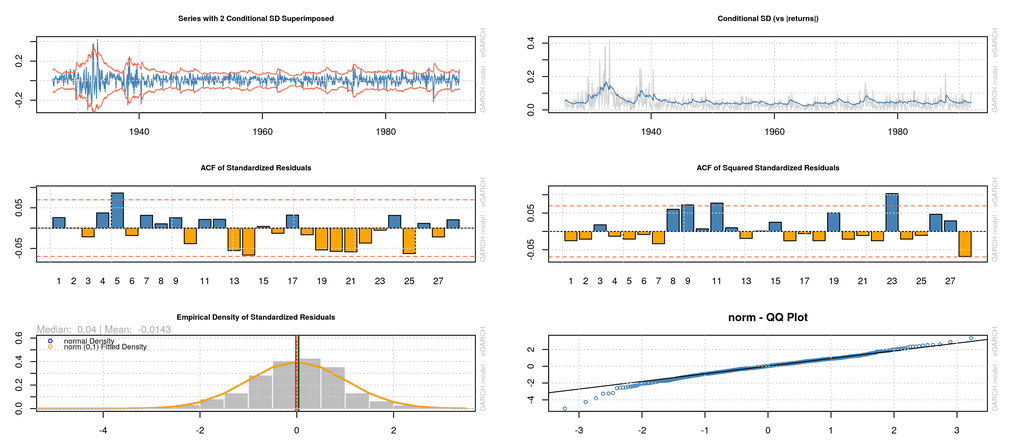

```r
par(mfrow=c(3,2));par(mar=c(3,3,3,3))
plot(fit_egarch,which=1)
plot(fit_egarch,which=3)
plot(fit_egarch,which=10)
plot(fit_egarch,which=11)
plot(fit_egarch,which=8)
plot(fit_egarch,which=9)
```

## 1.2. Threshold GARCH (TGARCH)

- The **TGARCH** model, also known as the **GJR-GARCH** model (named after the initials of its inventors) is another attempt for addressing the leverage effect.
- The TGARCH(p,q) model is

\begin{align*} \begin{cases} a_t = \sig_t\,\eps_t,\quad \eps_t\overset{i.i.d.}{\sim} F_\eps,\\\\ \displaystyle \sig_t^2 = \om + \sum_{i=1}^q \left(\al_i + \gam_i \1_{\{a_{t-i}<0\}}\right)\,a_{t-i}^2 + \sum_{j=1}^p \beta_j\sig_{t-j}^2. \end{cases} \end{align*}

- Here, \begin{align*} \1_{\{a_{t-i}<0\}}= \begin{cases} 1 &\text{if }a_{t-i}<0\\ 0 &\text{if }a_{t-i}\ge0 \end{cases} \end{align*} is the indicator function.
- Here, $\gam_1,\dots,\gam_q$ are the **leverage parameters**. We expect $\gam_i>0$ so that past negative returns have higher impact on volatility.
- Let us fit a TGARCH(1,1) model to the monthly excess return of S&P 500.
- We can do so by `ugarchfit()` function, by choose `model="gjrGARCH"` as the variance model.
- The fitted model is

\begin{align*} a_t = 0.006680 &+ \sig_t\,\eps_t,\quad \eps_t\overset{i.i.d.}{\sim} N(0,1),\\\\ \displaystyle \sig_t^2 = 0.000094 &+\left(0.074050 + 0.079963\,\1_{\{a_{t-1}<0\}}\right) a_{t-1}^2 \\ &+ 0.853944\,\sig_{t-1}^2. \end{align*}

- The lag-1 leverage parameter $\gam_1=0.079963$ is significant under 5% level (p-value is 0.036459). So, the TGARCH model also implies leverage effect in the S&P 500 returns.

```r
spec = ugarchspec(variance.model=list(model="gjrGARCH", garchOrder=c(1,1)),
                  mean.model=list(armaOrder=c(0,0)))
fit_tgarch = ugarchfit(data=rtn, spec=spec)
show(fit_tgarch)
```

```
*---------------------------------*
*          GARCH Model Fit        *
*---------------------------------*

Conditional Variance Dynamics
-----------------------------------
GARCH Model	: gjrGARCH(1,1)
Mean Model	: ARFIMA(0,0,0)
Distribution	: norm

Optimal Parameters
------------------------------------
        Estimate  Std. Error  t value Pr(>|t|)
mu      0.006680    0.001579   4.2298 0.000023
omega   0.000094    0.000032   2.9344 0.003342
alpha1  0.074050    0.026119   2.8351 0.004581
beta1   0.853944    0.022660  37.6858 0.000000
gamma1  0.079963    0.038227   2.0918 0.036459

Robust Standard Errors:
        Estimate  Std. Error  t value Pr(>|t|)
mu      0.006680    0.001724   3.8752 0.000107
omega   0.000094    0.000041   2.2824 0.022463
alpha1  0.074050    0.037191   1.9911 0.046471
beta1   0.853944    0.029094  29.3510 0.000000
gamma1  0.079963    0.061172   1.3072 0.191148

LogLikelihood : 1271.88

Information Criteria
------------------------------------

Akaike       -3.1992
Bayes        -3.1697
Shibata      -3.1993
Hannan-Quinn -3.1878

Weighted Ljung-Box Test on Standardized Residuals
------------------------------------
                        statistic p-value
```

[output cut: 39 more lines]

```
Negative Sign Bias   1.277 0.201847
Positive Sign Bias   0.493 0.622170
Joint Effect        14.456 0.002346 ***


Adjusted Pearson Goodness-of-Fit Test:
------------------------------------
  group statistic p-value(g-1)
1    20     29.57      0.05759
2    30     35.58      0.18625
3    40     38.51      0.49227
4    50     51.43      0.37863


Elapsed time : 0.1864173
```

- The model seems a good fit.

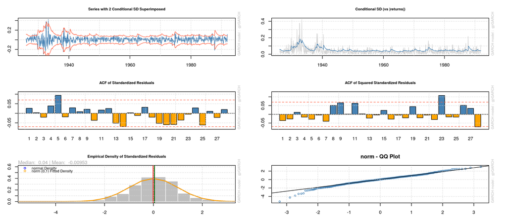

```r
par(mfrow=c(3,2));par(mar=c(3,3,3,3))
plot(fit_tgarch,which=1)
plot(fit_tgarch,which=3)
plot(fit_tgarch,which=10)
plot(fit_tgarch,which=11)
plot(fit_tgarch,which=8)
plot(fit_tgarch,which=9)
```

## 1.3. Asymmetric Power ARCH (APARCH)

- APARCH model generalizes TGARCH. Its goal is also to address the leverage effect.
- The APARC(p,q) model is

\begin{align*} \begin{cases} a_t = \sig_t\,\eps_t,\quad \eps_t\overset{i.i.d.}{\sim} F_\eps,\\\\ \displaystyle \sig_t^\del = \om + \sum_{i=1}^q \al_i\left(|a_{t-i}| - \gam_i a_{t-i}\right)^\del + \sum_{j=1}^p \beta_j\sig_{t-j}^\del. \end{cases} \end{align*}

- Here, $\del>0$ is a parameter, so, the APARCH model applies a Cox-Box transformation to volatility.
- $\gam_1, \dots, \gam_q$ are the leverage parameters.
- Several GARCH modes are special cases of APARCH. For example:
  - Simple GARCH: $\del=2$ and $\gam_i=0$
  - TGARCH: $\del=2$
- Let us fit an APARCH(1,1) model to the monthly excess return of S&P 500.
- We can do so by `ugarchfit()` function, by choose `model="apARCH"` as the variance model.
- The fitted model is

\begin{align*} a_t = 0.006760 &+ \sig_t\,\eps_t,\quad \eps_t\overset{i.i.d.}{\sim} N(0,1),\\\\ \displaystyle \sig_t^{1.107346} = 0.001295 &+ 0.122815\,\left(|a_{t-1}| - 0.315355 a_{t-1}\right)^{1.107346}\\ & + 0.869892\,\sig_{t-1}^{1.107346} \end{align*}

- The lag-1 leverage parameter $\gam_1=0.315355$ is, again, significant (p-value is 0.015904). So, the APARCH model implies leverage effect in the S&P 500 returns, as the previous models.

```r
spec = ugarchspec(variance.model=list(model="apARCH", garchOrder=c(1,1)),
                  mean.model=list(armaOrder=c(0,0)))
fit_aparch = ugarchfit(data=rtn, spec=spec)
show(fit_aparch)
```

```
*---------------------------------*
*          GARCH Model Fit        *
*---------------------------------*

Conditional Variance Dynamics
-----------------------------------
GARCH Model	: apARCH(1,1)
Mean Model	: ARFIMA(0,0,0)
Distribution	: norm

Optimal Parameters
------------------------------------
        Estimate  Std. Error  t value Pr(>|t|)
mu      0.006760    0.001577   4.2879 0.000018
omega   0.001295    0.001173   1.1041 0.269568
alpha1  0.122814    0.019433   6.3200 0.000000
beta1   0.869891    0.020061  43.3630 0.000000
gamma1  0.315369    0.130763   2.4118 0.015875
delta   1.107362    0.284521   3.8920 0.000099

Robust Standard Errors:
        Estimate  Std. Error  t value Pr(>|t|)
mu      0.006760    0.001728   3.9114 0.000092
omega   0.001295    0.001217   1.0638 0.287428
alpha1  0.122814    0.024486   5.0158 0.000001
beta1   0.869891    0.025447  34.1838 0.000000
gamma1  0.315369    0.178733   1.7645 0.077653
delta   1.107362    0.274366   4.0361 0.000054

LogLikelihood : 1274.973

Information Criteria
------------------------------------

Akaike       -3.2045
Bayes        -3.1691
Shibata      -3.2046
Hannan-Quinn -3.1909

Weighted Ljung-Box Test on Standardized Residuals
```

[output cut: 42 more lines]

```
Negative Sign Bias  1.2538 0.210279
Positive Sign Bias  0.4504 0.652540
Joint Effect       12.2293 0.006637 ***


Adjusted Pearson Goodness-of-Fit Test:
------------------------------------
  group statistic p-value(g-1)
1    20     27.19      0.10026
2    30     29.14      0.45798
3    40     49.21      0.12662
4    50     62.17      0.09806


Elapsed time : 0.4616127
```

- The model fit is good.

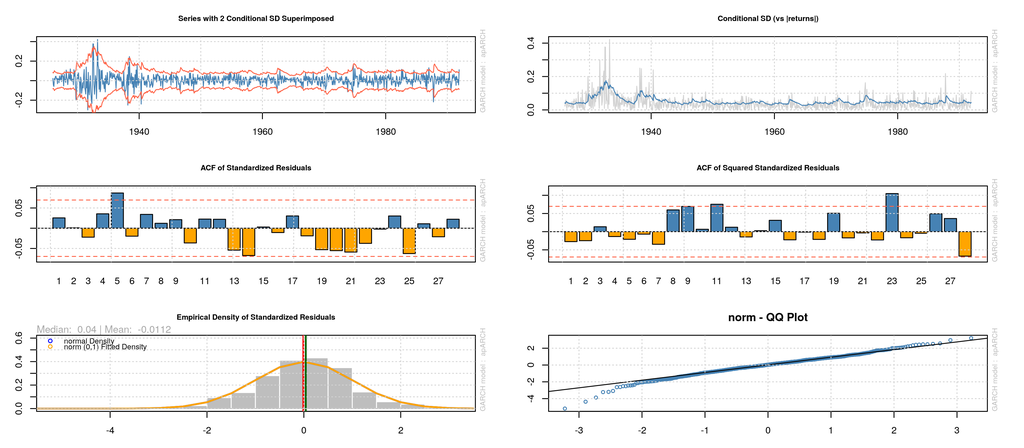

```r
par(mfrow=c(3,2));par(mar=c(3,3,3,3))
plot(fit_aparch,which=1)
plot(fit_aparch,which=3)
plot(fit_aparch,which=10)
plot(fit_aparch,which=11)
plot(fit_aparch,which=8)
plot(fit_aparch,which=9)
```

- We can also fit a TGARCH(1,1) model setting $\del=2$ in APARCH
- This can be done by using the `fixed.pars=list(delta=2)` as in the following R code.
- The fitted model is (is this model the same as the TGARCH model that we fitted before?)

\begin{align*} \begin{cases} a_t = 0.006680 + \sig_t\,\eps_t,\quad \eps_t\overset{i.i.d.}{\sim} N(0,1),\\\\ \displaystyle \sig_t^2 = 0.000094 + 0.110411\,\left(|a_{t-1}| - 0.181048 a_{t-1}\right)^2 + 0.853950\,\sig_{t-1}^2. \end{cases} \end{align*}

```r
spec = ugarchspec(variance.model=list(model="apARCH", garchOrder=c(1,1)),
                  mean.model=list(armaOrder=c(0,0)),
                  fixed.pars=list(delta=2))
fit_tgarch2 = ugarchfit(data=rtn, spec=spec)
show(fit_tgarch2)
```

```
*---------------------------------*
*          GARCH Model Fit        *
*---------------------------------*

Conditional Variance Dynamics
-----------------------------------
GARCH Model	: apARCH(1,1)
Mean Model	: ARFIMA(0,0,0)
Distribution	: norm

Optimal Parameters
------------------------------------
        Estimate  Std. Error  t value Pr(>|t|)
mu      0.006680    0.001579   4.2298 0.000023
omega   0.000094    0.000032   2.9344 0.003342
alpha1  0.110410    0.022232   4.9663 0.000001
beta1   0.853950    0.022658  37.6888 0.000000
gamma1  0.181051    0.092647   1.9542 0.050679
delta   2.000000          NA       NA       NA

Robust Standard Errors:
        Estimate  Std. Error  t value Pr(>|t|)
mu      0.006680    0.001585   4.2138 0.000025
omega   0.000094    0.000045   2.0630 0.039109
alpha1  0.110410    0.026100   4.2303 0.000023
beta1   0.853950    0.029874  28.5852 0.000000
gamma1  0.181051    0.134591   1.3452 0.178564
delta   2.000000          NA       NA       NA

LogLikelihood : 1271.88

Information Criteria
------------------------------------

Akaike       -3.1992
Bayes        -3.1697
Shibata      -3.1993
Hannan-Quinn -3.1878

Weighted Ljung-Box Test on Standardized Residuals
```

[output cut: 41 more lines]

```
Negative Sign Bias   1.277 0.201836
Positive Sign Bias   0.493 0.622145
Joint Effect        14.456 0.002346 ***


Adjusted Pearson Goodness-of-Fit Test:
------------------------------------
  group statistic p-value(g-1)
1    20     29.57      0.05759
2    30     35.58      0.18625
3    40     38.51      0.49227
4    50     51.43      0.37863


Elapsed time : 0.1721127
```

# 2. Linear regression with ARIMA+GARCH errors

- We can combine linear regression and ARIMA+GARCH models.
- Indeed, all the R functions that we have been using for fitting GARCH models allow for a predictor variable
- Let us illustrate by considering the weekly time series of 1-year US treasury constant maturity rate (y1) and 3-year US treasury constant maturity rate (y3) example from one of the previous lectures. Let c1=$\Del$y1 and c3=$\Del$y3 be the weekly rate changes.

1. 'WGS1YR'

2. 'WGS3YR'

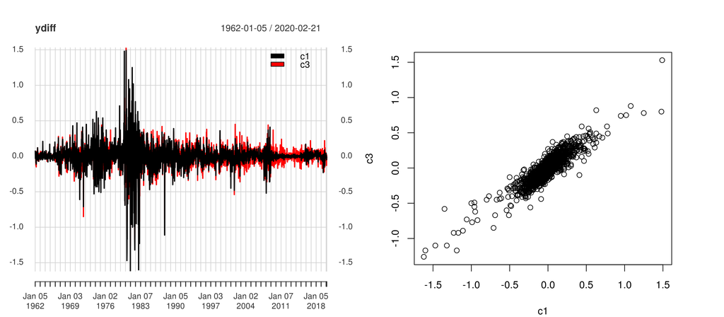

```r
library(quantmod)
getSymbols(c("WGS1YR","WGS3YR"), src="FRED", auto.assign=TRUE)
ydiff = diff(na.locf(merge(WGS1YR,WGS3YR))[index(WGS1YR)])
names(ydiff)=c('c1','c3')
c1= na.omit(as.numeric(ydiff$c1));c3=na.omit(as.numeric(ydiff$c3));
par(mfrow=c(1,2));par(mar=c(4,4,4,4))
plot(ydiff, legend.loc='topright', major.ticks = "years",
     grid.ticks.on = "years", grid.col = "lightgray")
plot(c1,c3,xlab="c1", ylab="c3")
```

- In the previous lecture, we fitted the following ARIMAX model for c3 with c1 as predictor

\begin{align*} \begin{cases} c3_t = -0.0002 + 0.7963\, c1_t + a_t\\ a_t = \eps_t + 0.1855\, \eps_{t-1}\\ \{\eps_t\} \sim \text{weak WN}(0, \sig_\eps^2=0.004292) \end{cases} \end{align*}

```r
library(forecast)
fit_arimax = arima(c3, order = c(0,0,1), xreg = c1)
fit_arimax
```

```
Call:
arima(x = c3, order = c(0, 0, 1), xreg = c1)

Coefficients:
         ma1  intercept      c1
      0.1850    -0.0003  0.7968
s.e.  0.0176     0.0014  0.0072

sigma^2 estimated as 0.004265:  log likelihood = 3972.26,  aic = -7936.51
```

```r
tsdiag_vol = function(model, lag, fitdf, span=0.5){
    par(mfrow=c(1,2));par(mar=c(3,3,3,3))
    plot(resid(model)**2, type="l", col=1,
         main = expression(residual^2))
    smoother = loess((resid(model)**2) ~ seq(1,length(resid(model))),
                     span=span)
    lines(seq(1,length(resid(model))),fitted(smoother),col=2)
    acf((resid(model)**2), main=expression("sample ACF of "~ residual^2))
    Box.test(resid(model)**2, lag = lag, type = "Ljung-Box", fitdf = fitdf)
}
tsdiag_norm = function(model){
    qqnorm(resid(model), datax = FALSE,
       xlab = "normal quantile",
       ylab = "sample quantile of residuals",
       main = "normal probability plot for residuals")
    qqline(resid(model), datax=FALSE, col = 2)
    shapiro.test(resid(model))
}
```

- Model diagnostic shows that the volatility is not constant.

```
	Box-Ljung test

data:  resid(model)^2
X-squared = 805.22, df = 10, p-value < 2.2e-16
```

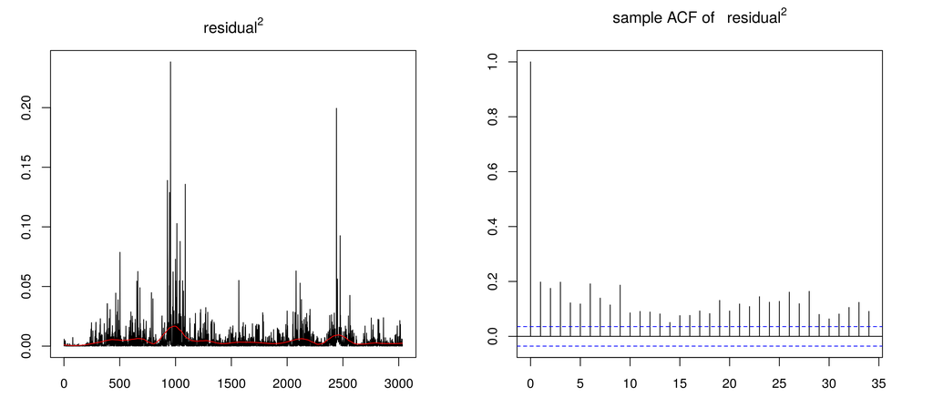

```r
tsdiag_vol(fit_arimax, lag=12, fitdf=2, span=0.15)
```

- ARCH(p) model would not lead to a parsimonious model.

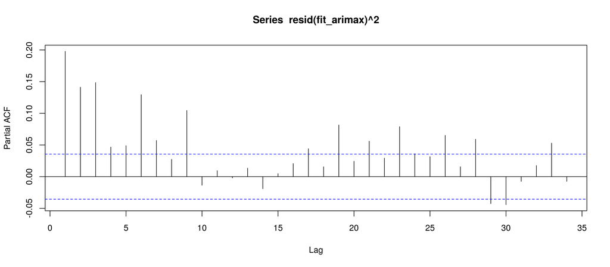

```r
pacf(resid(fit_arimax)^2)
```

- To model non-constant variance of the error, we consider an ARIMAX(0,0,1) + GARCH(1,1)

\begin{align*} \begin{cases} c3_t = 0.866586\, c1_t + \eta_t\\ \eta_t = a_t + 0.206477\, a_{t-1}\\ a_t = \sig_t \eps_t;\quad \eps_t \overset{i.i.d.}{\sim} N(0,1)\\ \sig^2 = 0.000021 + 0.079855\,a_{t-1}^2 + 0.919128\,\sig_{t-1}^2. \end{cases} \end{align*}

or,

\begin{align*} \begin{cases} c3_t - 0.866586\, c1_t = a_t + 0.206477\, a_{t-1}\\ a_t = \sig_t \eps_t;\quad \eps_t \overset{i.i.d.}{\sim} N(0,1)\\ \sig^2 = 0.000021 + 0.079855\,a_{t-1}^2 + 0.919128\,\sig_{t-1}^2. \end{cases} \end{align*}

```r
library(rugarch)
spec = ugarchspec(variance.model=list(model="sGARCH", garchOrder=c(1,1)),
                  mean.model=list(armaOrder=c(0,1), include.mean=FALSE,
                                  external.regressors=as.matrix(c1)))
fit_arimaxgarch = ugarchfit(data=c3, spec=spec)
show(fit_arimaxgarch)
```

```
*---------------------------------*
*          GARCH Model Fit        *
*---------------------------------*

Conditional Variance Dynamics
-----------------------------------
GARCH Model	: sGARCH(1,1)
Mean Model	: ARFIMA(0,0,1)
Distribution	: norm

Optimal Parameters
------------------------------------
        Estimate  Std. Error  t value Pr(>|t|)
ma1     0.206477    0.018837  10.9613  0.00000
mxreg1  0.866586    0.010770  80.4663  0.00000
omega   0.000021    0.000008   2.6997  0.00694
alpha1  0.079855    0.009693   8.2381  0.00000
beta1   0.919128    0.009744  94.3252  0.00000

Robust Standard Errors:
        Estimate  Std. Error  t value Pr(>|t|)
ma1     0.206477    0.020830   9.9125  0.00000
mxreg1  0.866586    0.029838  29.0433  0.00000
omega   0.000021    0.000015   1.4081  0.15911
alpha1  0.079855    0.015839   5.0416  0.00000
beta1   0.919128    0.017105  53.7359  0.00000

LogLikelihood : 4383.124

Information Criteria
------------------------------------

Akaike       -2.8870
Bayes        -2.8771
Shibata      -2.8870
Hannan-Quinn -2.8834

Weighted Ljung-Box Test on Standardized Residuals
------------------------------------
                        statistic p-value
```

[output cut: 39 more lines]

```
Negative Sign Bias 1.19444 0.2324
Positive Sign Bias 0.97701 0.3286
Joint Effect       2.39130 0.4953


Adjusted Pearson Goodness-of-Fit Test:
------------------------------------
  group statistic p-value(g-1)
1    20     50.00    1.310e-04
2    30     67.45    6.725e-05
3    40     78.97    1.593e-04
4    50     87.10    6.588e-04


Elapsed time : 0.388608
```

- The mean and volatility equations seems to be adequate according to the Ljung-Box tests. However, the standardized residuals may not be normal.

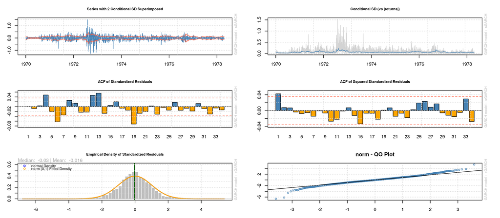

```r
par(mfrow=c(3,2));par(mar=c(3,3,3,3))
plot(fit_arimaxgarch,which=1)
plot(fit_arimaxgarch,which=3)
plot(fit_arimaxgarch,which=10)
plot(fit_arimaxgarch,which=11)
plot(fit_arimaxgarch,which=8)
plot(fit_arimaxgarch,which=9)
```

- Finally, we fit an ARIMAX+GARCH(1,1) model with student-t errors.

\begin{align*} \begin{cases} c3_t - 0.886443\, c1_t = a_t + 0.200473\, a_{t-1}\\ a_t = \sig_t \eps_t;\quad \eps_t \overset{i.i.d.}{\sim} t_{\nu=6.861488}\\ \sig^2 = 0.000022 + 0.085506\,a_{t-1}^2 + 0.913494\,\sig_{t-1}^2. \end{cases} \end{align*}

```r
library(rugarch)
spec = ugarchspec(variance.model=list(model="sGARCH", garchOrder=c(1,1)),
                  mean.model=list(armaOrder=c(0,1), include.mean=FALSE,
                                  external.regressors=as.matrix(c1)),
                  distribution.model="std")
fit_arimaxgarch_t = ugarchfit(data=c3, spec=spec)
show(fit_arimaxgarch_t)
```

```
*---------------------------------*
*          GARCH Model Fit        *
*---------------------------------*

Conditional Variance Dynamics
-----------------------------------
GARCH Model	: sGARCH(1,1)
Mean Model	: ARFIMA(0,0,1)
Distribution	: std

Optimal Parameters
------------------------------------
        Estimate  Std. Error  t value Pr(>|t|)
ma1     0.200473    0.018450  10.8656 0.000000
mxreg1  0.886443    0.011378  77.9080 0.000000
omega   0.000022    0.000010   2.2444 0.024808
alpha1  0.085506    0.011775   7.2615 0.000000
beta1   0.913494    0.011743  77.7925 0.000000
shape   6.861488    0.787687   8.7109 0.000000

Robust Standard Errors:
        Estimate  Std. Error  t value Pr(>|t|)
ma1     0.200473    0.019514  10.2735  0.00000
mxreg1  0.886443    0.029699  29.8474  0.00000
omega   0.000022    0.000016   1.4164  0.15666
alpha1  0.085506    0.014253   5.9993  0.00000
beta1   0.913494    0.016038  56.9597  0.00000
shape   6.861488    0.779973   8.7971  0.00000

LogLikelihood : 4451.293

Information Criteria
------------------------------------

Akaike       -2.9313
Bayes        -2.9194
Shibata      -2.9313
Hannan-Quinn -2.9270

Weighted Ljung-Box Test on Standardized Residuals
```

[output cut: 42 more lines]

```
Negative Sign Bias 0.97243 0.3309
Positive Sign Bias 1.03381 0.3013
Joint Effect       2.02601 0.5670


Adjusted Pearson Goodness-of-Fit Test:
------------------------------------
  group statistic p-value(g-1)
1    20     17.23       0.5745
2    30     27.54       0.5424
3    40     39.30       0.4565
4    50     47.83       0.5207


Elapsed time : 0.3150537
```

- The model is a good fit.

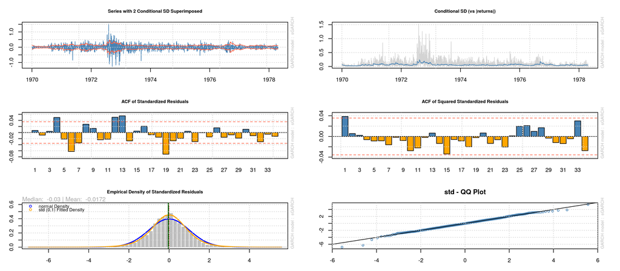

```r
par(mfrow=c(3,2));par(mar=c(3,3,3,3))
plot(fit_arimaxgarch_t,which=1)
plot(fit_arimaxgarch_t,which=3)
plot(fit_arimaxgarch_t,which=10)
plot(fit_arimaxgarch_t,which=11)
plot(fit_arimaxgarch_t,which=8)
plot(fit_arimaxgarch_t,which=9)
```

# 3. Cointegration

- As we have seen, one way to create stationary process out of non-stationary ones is by differencing. We have called such processes integrated
- Sometimes, a linear combination of two (or more) non-stationary processes is stationary. Such processes are said to be **"cointegrated"**

**Definition:**

- Processes $\{Y_{t,1}\}, \dots, \{Y_{t,k}\}$ are **"cointegrated"** if:

  **(i)** They are non-stationary; and,

  **(ii)** There is at least one linear combination $Z_t = \beta_1 Y_{t,1} + \dots + \beta_n Y_{t,k}$ that is stationary
- In such cases, $\{Z_t\}$ is called a **"cointegrating relationship"** and $(\beta_1,\dots,\beta_n)$ is called a **"cointegrating vector"**

**Example:**

- Consider the processes $\{Y_{t,1}\}$ and $\{Y_{t,2}\}$ given by

\begin{align*} \begin{cases} \Del Y_{t,1} = \eta_1 Z_{t-1} + \eps_{t,1}\\ \Del Y_{t,2} = \eta_2 Z_{t-1} + \eps_{t,2}\\ Z_{t} = Y_{t,1} - c Y_{t,2} \end{cases} \end{align*}

- Here $\{(\eps_{t,1},\eps_{t,2})\}$ is weak WN and $c$, $\eta_1$, and $\eta_2$ are constants
- Note that $\{Z_t\}$ is an AR(1) process:

\begin{align*} \Del Z_t = \Del Y_{t,1} - c \Del Y_{t,2} = (\eta_1-c\eta_2) Z_{t-1} + (\eps_{t,1}-c\eps_{t,2}) \end{align*}

- Indeed, by defining a new weak WN $\eps_{t,3} = \eps_{t,1}-c\eps_{t,2}$, we may write

\begin{align*} Z_t = (1+\eta_1-c\eta_2) Z_{t-1} + \eps_{t,3} \end{align*}

- Assume that $|1+\eta_1$ $-c\eta_2|$ $<1 \Longleftrightarrow$ $ -2<\eta_1$ $-c\eta_2$ $<0$
- Then $\{Z_t\}$ is stationary
- Note, however, that $\{Y_{t,1}\}$ and $\{Y_{t,2}\}$ are non-stationary (why?). Thus, $\{Y_{t,1}\}$ and $\{Y_{t,2}\}$ are cointegrated, with cointegrating vector $(1,-c)$
- The main application of cointegration in finance is to identify statistical arbitrage
- There is a fundamental difference between **cointegrated** and **correlated** processes.
- Processes that are correlated (but not cointegrated) move in the same direction. However, there is no guarantee that the value of the processes stay near each other.
- In contrast, cointegrated process have a long-term equilibrium and their values will not get too far from each other
- There are two main approaches to cointegration analysis:
  1. Engle-Granger two step method: Simple, but not suitable for high-dimensional setting
  2. Johansen method: more powerful and suitable for high-dimensional cases

# 3.1. The two step method

- Consider time series $\{Y_{t,1}\}, \dots, \{Y_{t,n}\}$
- **Step 1:** Regress $\{Y_{1,t}\}$ on the remaining time series: $Y_{t,1} = \beta_0 + \beta_2 Y_{t,2} + \dots + \beta_n Y_{t,n} + Z_t$ Let $\{\Zh_t\}$ be the residual of this regression
- **Step 2:** Test if $\{\Zh_t\}$ is stationary.
  - For this step, use unit root test that are designed for the two-step method, such as the Phillips-Ouliaris test (alternative hypothesis is cointegration)
  - If the test indicates cointegration, then $\{\Zh_t\}$ is the cointegrating relation and $(1,-\beta_2,\dots,-\beta_n)$ is a cointegrating vector
- Let us illustrate the two-step method by an example
- Consider the prices of Microsof and IBM stock from 2001-2007

1. 'MSFT'

2. 'IBM'

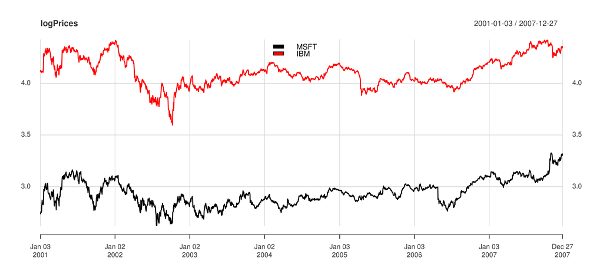

```r
getSymbols(c("MSFT", "IBM"), from="2001-01-03", to="2007-12-28", src="yahoo")
logPrices = log(na.omit(merge(MSFT$MSFT.Adjusted,IBM$IBM.Adjusted)))
names(logPrices) = c("MSFT", "IBM")
plot(logPrices, legend.loc='top', major.ticks = "years",
     grid.ticks.on = "years", grid.col = "lightgray")
```

- First, we check that the log prices are not stationary

```r
library(tseries)
adf.test(coredata(logPrices[,1]))
pp.test(coredata(logPrices[,1]))
kpss.test(coredata(logPrices[,1]))
```

```
	Augmented Dickey-Fuller Test

data:  coredata(logPrices[, 1])
Dickey-Fuller = -2.4747, Lag order = 12, p-value = 0.3774
alternative hypothesis: stationary
```

```
	Phillips-Perron Unit Root Test

data:  coredata(logPrices[, 1])
Dickey-Fuller Z(alpha) = -19.124, Truncation lag parameter = 8, p-value
= 0.08499
alternative hypothesis: stationary
```

```
	KPSS Test for Level Stationarity

data:  coredata(logPrices[, 1])
KPSS Level = 5.7658, Truncation lag parameter = 8, p-value = 0.01
```

```r
adf.test(coredata(logPrices[,2]))
pp.test(coredata(logPrices[,2]))
kpss.test(coredata(logPrices[,2]))
```

```
	Augmented Dickey-Fuller Test

data:  coredata(logPrices[, 2])
Dickey-Fuller = -2.5054, Lag order = 12, p-value = 0.3644
alternative hypothesis: stationary
```

```
	Phillips-Perron Unit Root Test

data:  coredata(logPrices[, 2])
Dickey-Fuller Z(alpha) = -11.965, Truncation lag parameter = 8, p-value
= 0.4424
alternative hypothesis: stationary
```

```
	KPSS Test for Level Stationarity

data:  coredata(logPrices[, 2])
KPSS Level = 2.0592, Truncation lag parameter = 8, p-value = 0.01
```

- **Step1:** Finding the cointegrating relation
- We get the following fitted model

\begin{align*} \log MSFT_{t} = 0.26481 + 0.65064 \log IBM_t + Z_t \end{align*}

- This indicates a conintegrating relationship

\begin{align*} Z_t = \log MSFT_{t} - 0.65064 \log IBM_t - 0.26481 \end{align*}

```r
fit = lm(coredata(logPrices[,1])~coredata(logPrices[,2]))
summary(fit)
```

```
Call:
lm(formula = coredata(logPrices[, 1]) ~ coredata(logPrices[,
    2]))

Residuals:
     Min       1Q   Median       3Q      Max
-0.21687 -0.05602 -0.01065  0.06844  0.21801

Coefficients:
                         Estimate Std. Error t value Pr(>|t|)
(Intercept)               0.26481    0.05447   4.862 1.27e-06 ***
coredata(logPrices[, 2])  0.65064    0.01325  49.106  < 2e-16 ***
---
Signif. codes:  0 ‘***’ 0.001 ‘**’ 0.01 ‘*’ 0.05 ‘.’ 0.1 ‘ ’ 1

Residual standard error: 0.07972 on 1753 degrees of freedom
Multiple R-squared:  0.5791,	Adjusted R-squared:  0.5788
F-statistic:  2411 on 1 and 1753 DF,  p-value: < 2.2e-16
```

- **Step 2:** Checking that residuals of the regression are stationary

```r
adf.test(resid(fit))
pp.test(resid(fit))
kpss.test(resid(fit))
```

```
	Augmented Dickey-Fuller Test

data:  resid(fit)
Dickey-Fuller = -3.6013, Lag order = 12, p-value = 0.03254
alternative hypothesis: stationary
```

```
	Phillips-Perron Unit Root Test

data:  resid(fit)
Dickey-Fuller Z(alpha) = -39.665, Truncation lag parameter = 8, p-value
= 0.01
alternative hypothesis: stationary
```

```
	KPSS Test for Level Stationarity

data:  resid(fit)
KPSS Level = 7.2647, Truncation lag parameter = 8, p-value = 0.01
```

- We should not use ordinary unit-root test!
- We should instead use tests that are designed for cointegration analysis.
- We use the Philips-Ouliaris cointegration test, with the alternative hypothesis that the residuals are stationary (i.e. cointegration)
- The test indicates that the log prices are cointegrated

```r
po.test(coredata(logPrices))
```

```
	Phillips-Ouliaris Cointegration Test

data:  coredata(logPrices)
Phillips-Ouliaris demeaned = -27.902, Truncation lag parameter = 17,
p-value = 0.01139
```

- Alternatively, you can conduct both steps using `ca.po()` function of `urca` package.
- It does not report the p-value, but the test-statistic and its critical values for different test level
- "test-stat $>$ critical value" is interpreted as cointegration.
- In this case, test-stat = 52.4945, and the 1% critical value is 48. So, the alternative assumption of cointegration is accepted.

```r
library(urca)
coint_po = ca.po(logPrices, demean="constant")
summary(coint_po)
```

```
########################################
# Phillips and Ouliaris Unit Root Test #
########################################

Test of type Pu
detrending of series with constant only


Call:
lm(formula = z[, 1] ~ z[, -1])

Residuals:
     Min       1Q   Median       3Q      Max
-0.21687 -0.05602 -0.01065  0.06844  0.21801

Coefficients:
            Estimate Std. Error t value Pr(>|t|)
(Intercept)  0.26481    0.05447   4.862 1.27e-06 ***
z[, -1]      0.65064    0.01325  49.106  < 2e-16 ***
---
Signif. codes:  0 ‘***’ 0.001 ‘**’ 0.01 ‘*’ 0.05 ‘.’ 0.1 ‘ ’ 1

Residual standard error: 0.07972 on 1753 degrees of freedom
Multiple R-squared:  0.5791,	Adjusted R-squared:  0.5788
F-statistic:  2411 on 1 and 1753 DF,  p-value: < 2.2e-16


Value of test-statistic is: 52.4945

Critical values of Pu are:
                  10pct   5pct    1pct
critical values 27.8536 33.713 48.0021
```

- Let us plot the cointegrating relationship

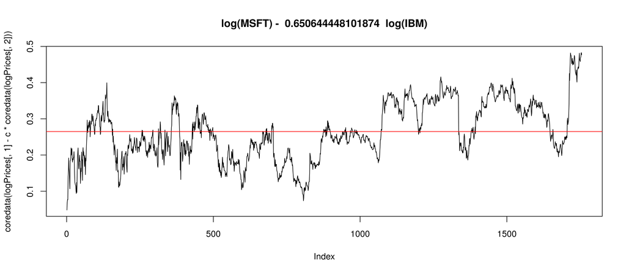

```r
c = coefficients(fit)[[2]] # the cointegrating vector is (1,-c)
plot(coredata(logPrices[,1] - c * coredata(logPrices[,2])),
     type="l", col=1,
     main = paste("log(MSFT) - ", c, " log(IBM)"))
abline(h = coefficients(fit)[[1]], col=2)
```